# Unifying individual differences in personality, predictability, and plasticity: a practical guide - ‘brms’ model code

Rose E. O’Dea, Daniel W.A. Noble, Shinichi Nakagawa

2021-08-31

# Introduction

This supplement introduces readers to the calculations and modelling approaches, reviewed by:  
Rose E. O’Dea, Daniel W.A. Noble and Shinichi Nakagawa 2021. *Unifying individual differences in personality, predictability, and plasticity: a practical guide*, using the `brms` R package (which interfaces with `stan`).

We only fit an exemplar set of models from our worked example. More specifically, we focus on a subset of models using two traits (aggression and activity) to demonstrate how to fit single- and double- hierarchical generalized linear models (abbreviated as SHGLM and DHGLM, respectively). This includes uni-variate and bi-variate (two trait) models. For a selection of models we also show how to: 1) calculate repeatability and the coefficient of variation for the mean and dispersion models, and 2) extract and manipulate individual BLUPs (best linear unbiased predictors) to estimate between-individual correlations outlined in our manuscript.

# R Packages, Data and Model Fits

Readers will need to download the data and model fits (unless they want to rerun the models) from our [Open Science Framework (OSF) Project Site](http://doi.org/10.17605/OSF.IO/V3QAX). Once downloaded and placed in your working directory run the following code to load the data sets and R packages:

```r
# install.packages('pacman') Load Libraries and relevant data
pacman::p_load(klippy, brms, dplyr, here, flextable)


# Get the raw data. We need this for back transformation from z-scale making
# sure fish_ID is coded as a factor (done automatically before R v4+)
# square-root transforming novel and predator response variables z-scaling all
# variables

dat <- read.csv("./Data/data_predictability_worked_example.csv")

dat <- dat %>%
    dplyr::mutate(fish_ID = factor(fish_ID, levels = unique(fish_ID)), age.Z = scale(age_days),
        activity = scale(dist_m_Activity), aggression = scale(stim.dist_0_5cm_dur_Aggression),
        novel = scale(sqrt(stim.dist_0_10cm_dur_Novel)), predator = scale(sqrt(stim.dist_0_10cm_dur_Predator)),
        social = scale(stim.dist_0_5cm_dur_Social), id = fish_ID)

# processed Stan models for comparison
load("./Results/stanmodels_processed.Rdata")
stanproc_personality_shglm_aggression <- stanmods[stanmods$model == "personality shglm" &
    stanmods$behaviour1 == "aggression", ]
stanproc_personality_dhglm_aggression <- stanmods[stanmods$model == "personality dhglm" &
    stanmods$behaviour1 == "aggression", ]
stanproc_personality_plasticity_shglm_aggression <- stanmods[stanmods$model == "personality & plasticity shglm" &
    stanmods$behaviour1 == "aggression", ]
stanproc_personality_plasticity_dhglm_aggression <- stanmods[stanmods$model == "personality & plasticity dhglm" &
    stanmods$behaviour1 == "aggression", ]
stanproc_bivar_shglm_activity_aggression <- stanmods[stanmods$model == "bivariate shglm" &
    stanmods$behaviour1 == "activity" & stanmods$behaviour2 == "aggression", ]
stanproc_bivar_dhglm_activity_aggression <- stanmods[stanmods$model == "bivariate dhglm" &
    stanmods$behaviour1 == "activity" & stanmods$behaviour2 == "aggression", ]
```

# Load Functions

Load in the functions that will be needed to process output from the models to derive the various estimates needed for calculating the necessary parameters:

```r
# Population-level intercept
func_Bp <- function(B0, B1) {
    Bp <- (2 * B0 + B1)/2  # assumes 50/50 ratio for B1 (in our example = sex)
    return(Bp)
}

# Total variance, equation 40. Function for summing dataframe of variance
# components
func_sum_var <- function(vars) {
    sum_var <- sapply(1:nrow(vars), function(x) sum(vars[x, ], na.rm = T))
    return(sum_var)
}


# Variance for fixed effects
func_var_fixed <- function(B1, B2, data) {
    # model matrix for fixed effects
    X <- model.matrix(~1 + sex + age.Z, data = data)
    X1 <- X[, 2]
    X2 <- X[, 3]
    var_fixed <- sapply(1:length(B1), function(x) var(X1 * B1[x] + X2 * B2[x]))
    return(var_fixed)
}

# within-individual standard deviation
func_var_within <- function(Bpv, sigma_v0, var_fixed_v) {

    # summed variance components
    var_within_exp <- func_sum_var(vars = data.frame(sigma_v0^2, var_fixed_v))
    # conversion back from log scale
    var_within <- func_ln_convert(mu_ln = Bpv, sigma_ln = sqrt(var_within_exp))$mu_raw

    return(var_within)
}

# Repeatability for the dispersion model for DHGLM
func_Rp_var <- function(Bpv, sigma_v0, var_fixed_v, var_p) {

    # sum of IDv0 and fixedV = total variance in residual variance on
    # log-normal scale:
    var_residvar_exp <- func_sum_var(vars = data.frame(sigma_v0^2, var_fixed_v))
    # converting back to same scale as mean model:
    sigma_residvar <- func_ln_convert(mu_ln = Bpv, sigma_ln = sqrt(var_residvar_exp))$sigma_raw

    # variance in phenotypic variance
    total_var_var <- 2 * var_p^2 + 3 * sigma_residvar^2

    # getting variance in individual component through the preservation of the
    # proportionality (i.e. ratio method)
    ratio <- sigma_v0^2/(var_residvar_exp)
    var_ID <- sigma_residvar^2 * ratio

    Rp_var <- var_ID/total_var_var
    return(Rp_var)
}

# Convert from ln to raw scale
func_ln_convert <- function(mu_ln, sigma_ln) {

    mu_raw <- exp(mu_ln + sigma_ln^2/2)
    var_raw <- (exp(sigma_ln^2) - 1) * exp(2 * mu_ln + sigma_ln^2)

    x <- data.frame(mu_raw, sigma_raw = sqrt(var_raw))
    return(x)
}


# Function takes random slopes and intercepts and calculates the between
# individual correlation between them and returns this correlation for each row
# (i.e., posterior sampling iteration). It returns a posterior distribution of
# the correlation.

cor_calc <- function(slopes, intercepts) {
    cors <- c()
    for (i in 1:dim(intercepts)[1]) {
        cors <- c(cors, cor(as.numeric(slopes[i, ]), as.numeric(intercepts[i, ])))
    }
    return(cors)
}
```

# Running *brms* SHGLM and DHGLM models

## Personality (SHGLM)

### Model

Let’s start by fitting a model to the aggression data to estimate “personality”.

```r
########### Personality ########## EXAMPLE 1:
########### standata_personality_shglm_aggression; replicates the following
########### model stan_personality_shglm_aggression <- stan(file =
########### './Code/stancode_personality_shglm.stan', data =
########### standata_personality_shglm_aggression, pars = save_pars, iter =
########### 6000, warmup = 2000, chains = 3, cores = 3)

# Fit a model for aggression that includes fixed effects of sex and
# z-transformed age plus a random intercept for individual ID
rerun1 = FALSE

if (rerun1) {
    formula_personality_shglm_aggression <- bf(aggression ~ sex + age.Z + (1 | id))
    brms_personality_shglm_aggression <- brms::brm(formula_personality_shglm_aggression,
        data = dat, iter = 6000, warmup = 2000, chains = 3, cores = 3, save_pars = save_pars())
    saveRDS(brms_personality_shglm_aggression, "./Models/brms_models/brms_personality_shglm_aggression")
} else {
    brms_personality_shglm_aggression <- readRDS(here::here("Models/brms_models",
        "brms_personality_shglm_aggression"))
}

summary(brms_personality_shglm_aggression)
```

```
##  Family: gaussian
##   Links: mu = identity; sigma = identity
## Formula: aggression ~ sex + age.Z + (1 | id)
##    Data: dat (Number of observations: 2766)
## Samples: 3 chains, each with iter = 6000; warmup = 2000; thin = 1;
##          total post-warmup samples = 12000
##
## Group-Level Effects:
## ~id (Number of levels: 248)
##               Estimate Est.Error l-95% CI u-95% CI Rhat Bulk_ESS Tail_ESS
## sd(Intercept)     0.43      0.03     0.38     0.49 1.00     4368     7547
##
## Population-Level Effects:
##           Estimate Est.Error l-95% CI u-95% CI Rhat Bulk_ESS Tail_ESS
## Intercept     0.24      0.04     0.16     0.33 1.00     5561     7814
## sexmale      -0.51      0.06    -0.64    -0.38 1.00     5465     7105
## age.Z        -0.31      0.02    -0.34    -0.28 1.00    24815     8824
##
## Family Specific Parameters:
##       Estimate Est.Error l-95% CI u-95% CI Rhat Bulk_ESS Tail_ESS
## sigma     0.82      0.01     0.80     0.85 1.00    17531     9188
##
## Samples were drawn using sampling(NUTS). For each parameter, Bulk_ESS
## and Tail_ESS are effective sample size measures, and Rhat is the potential
## scale reduction factor on split chains (at convergence, Rhat = 1).
```

### Calculate CVm and Rpm

We demonstrate the calculation of the coefficient of variation ($CV_m$) and repeatability ($Rp_m$) of the mean from our SHGLM. We compare the results to the `stan` model results (i.e., `stanproc_`) from our worked example.

```r
# (Step 1): Get the average intercept from fixed effects.
Bpm <- func_Bp(B0 = brms::posterior_samples(brms_personality_shglm_aggression, pars = "Intercept")[,
    1], B1 = brms::posterior_samples(brms_personality_shglm_aggression, pars = "sex")[,
    1])
mean(Bpm)
mean(stanproc_personality_shglm_aggression$B1_pm)

# (Step 2): Extract random intercept for ID. Numerator for eqn 34. Note these
# are standard deviations for between-individual differences in the mean model
sigma_m0 <- brms::posterior_samples(brms_personality_shglm_aggression, pars = "sd_id__Intercept")[,
    1]
mean(sigma_m0)
mean(stanproc_personality_shglm_aggression$sigma_ID1_m0)

# (Step 3): Extract residual standard deviation
sigma_e <- brms::posterior_samples(brms_personality_shglm_aggression, pars = "sigma")[,
    1]
mean(sigma_e)
mean(stanproc_personality_shglm_aggression$sigma_e1)

# (Step 4): Calculate fixed effect variance
var_fixed <- func_var_fixed(B1 = brms::posterior_samples(brms_personality_shglm_aggression,
    pars = "sex")[, 1], B2 = brms::posterior_samples(brms_personality_shglm_aggression,
    pars = "age.Z")[, 1], data = dat)
mean(var_fixed)
mean(stanproc_personality_shglm_aggression$var1_fixed_m)

# (Step 5): Calculate total phenotypic variance
total_var <- func_sum_var(vars = data.frame(sigma_m0^2, var_fixed, sigma_e^2))
mean(total_var)
mean(stanproc_personality_shglm_aggression$var1_p)

# (Step 6): Convert back from z-scale
mu_unscaled <- mean(dat$stim.dist_0_5cm_dur_Aggression)
sigma_unscaled <- sd(dat$stim.dist_0_5cm_dur_Aggression)

Mu <- Bpm * sigma_unscaled + mu_unscaled
Sigma <- sqrt(total_var) * sigma_unscaled

indiv_sd <- sqrt(sigma_m0^2) * sigma_unscaled

# (Step 7): Calculate CVm
CV_m <- indiv_sd/Mu
mean(CV_m)
mean(stanproc_personality_shglm_aggression$CV1_mu)

# (Step 8): Calculate Rpm\t\t
Rp_m <- sigma_m0^2/total_var
mean(Rp_m)
mean(stanproc_personality_shglm_aggression$Rp1_mu)
```

```r
# Results
personality_results <- data.frame(CVm = mean(CV_m), CVm.L = quantile(CV_m, 0.025),
    CVm.U = quantile(CV_m, 0.975), Rpm = mean(Rp_m), Rpm.L = quantile(Rp_m, 0.025),
    Rpm.U = quantile(Rp_m, 0.975))
flextable::flextable(personality_results) %>%
    flextable::compose(part = "header", j = c(1:6), value = c(as_paragraph("CV",
        as_sub("m")), as_paragraph("95% CI", as_sub("lower")), as_paragraph("95% CI",
        as_sub("upper")), as_paragraph("Rp", as_sub("m")), as_paragraph("95% CI",
        as_sub("lower")), as_paragraph("95% CI", as_sub("upper")))) %>%
    align(align = "center", part = "header") %>%
    fit_to_width(max_width = 7)
```

| CVm | 95% CIlower | 95% CIupper | Rpm | 95% CIlower | 95% CIupper |
| --- | --- | --- | --- | --- | --- |
| 0.27 | 0.24 | 0.31 | 0.18 | 0.15 | 0.22 |

## Personality & Predictability (DHGLM)

### Model

Let’s start by fitting a model to the aggression data to estimate both “personality” (mean model) and “predictability” (dispersion model).

```r
####### Personality / Predictability ########## EXAMPLE 2:
####### standata_personality_dhglm_aggression; replicates the following model
####### stan_personality_dhglm_aggression <- stan(file =
####### './Code/stancode_personality_dhglm.stan', data =
####### standata_personality_dhglm_aggression, pars = save_pars, iter = 6000,
####### warmup = 2000, chains = 3, cores = 3)\t \t

rerun2 = FALSE

if (rerun2) {
    formula_personality_dhglm_aggression <- bf(aggression ~ sex + age.Z + (1 | p |
        id), sigma ~ sex + age.Z + (1 | p | id))

    brms_personality_dhglm_aggression <- brm(formula_personality_dhglm_aggression,
        data = dat, iter = 6000, warmup = 2000, chains = 3, cores = 3, save_pars = save_pars())

    saveRDS(brms_personality_dhglm_aggression, "./Models/brms_models/brms_personality_dhglm_aggression")
} else {
    brms_personality_dhglm_aggression <- readRDS(here::here("Models/brms_models",
        "brms_personality_dhglm_aggression"))
}

summary(brms_personality_dhglm_aggression)
```

```
##  Family: gaussian
##   Links: mu = identity; sigma = log
## Formula: aggression ~ sex + age.Z + (1 | p | id)
##          sigma ~ sex + age.Z + (1 | p | id)
##    Data: dat (Number of observations: 2766)
## Samples: 3 chains, each with iter = 6000; warmup = 2000; thin = 1;
##          total post-warmup samples = 12000
##
## Group-Level Effects:
## ~id (Number of levels: 248)
##                                Estimate Est.Error l-95% CI u-95% CI Rhat
## sd(Intercept)                      0.44      0.03     0.39     0.49 1.00
## sd(sigma_Intercept)                0.22      0.02     0.18     0.26 1.00
## cor(Intercept,sigma_Intercept)     0.43      0.11     0.22     0.63 1.00
##                                Bulk_ESS Tail_ESS
## sd(Intercept)                      3633     6106
## sd(sigma_Intercept)                4652     6684
## cor(Intercept,sigma_Intercept)     3494     5314
##
## Population-Level Effects:
##                 Estimate Est.Error l-95% CI u-95% CI Rhat Bulk_ESS Tail_ESS
## Intercept           0.24      0.04     0.15     0.33 1.00     2720     5165
## sigma_Intercept    -0.21      0.03    -0.26    -0.15 1.00     5314     8258
## sexmale            -0.50      0.06    -0.63    -0.38 1.00     2221     4096
## age.Z              -0.30      0.02    -0.33    -0.27 1.00    11275     8938
## sigma_sexmale      -0.09      0.04    -0.17    -0.01 1.00     5492     7536
## sigma_age.Z        -0.11      0.02    -0.14    -0.08 1.00    10432     9730
##
## Samples were drawn using sampling(NUTS). For each parameter, Bulk_ESS
## and Tail_ESS are effective sample size measures, and Rhat is the potential
## scale reduction factor on split chains (at convergence, Rhat = 1).
```

### Calculate CVm and Rpm

Here we now have two separate models: a mean model and a dispersion model.

```r
################################# Mean and Dispersion Parameters

# (Step 1): Extract the population coefficients for mean model
B0_m <- brms::posterior_samples(brms_personality_dhglm_aggression, pars = "b_Intercept")[,
    1]
B1_m <- brms::posterior_samples(brms_personality_dhglm_aggression, pars = "b_sex")[,
    1]
B2_m <- brms::posterior_samples(brms_personality_dhglm_aggression, pars = "b_age.Z")[,
    1]

mean(B0_m)
mean(stanproc_personality_dhglm_aggression$B1_m0)

mean(B1_m)
mean(stanproc_personality_dhglm_aggression$B1_m1)

mean(B2_m)
mean(stanproc_personality_dhglm_aggression$B1_m2)

# (Step 2): Extract the population coefficients for dispersion model\t
B0_sd_exp <- brms::posterior_samples(brms_personality_dhglm_aggression, pars = "b_sigma_Intercept")[,
    1]
B1_sd_exp <- brms::posterior_samples(brms_personality_dhglm_aggression, pars = "b_sigma_sex")[,
    1]
B2_sd_exp <- brms::posterior_samples(brms_personality_dhglm_aggression, pars = "b_sigma_age.Z")[,
    1]

# for comparison between ln(var) and ln(sd) models, need to multiple ln(sd) by
# 2
mean(2 * B0_sd_exp)
mean(stanproc_personality_dhglm_aggression$B1_v0)

mean(2 * B1_sd_exp)
mean(stanproc_personality_dhglm_aggression$B1_v1)

mean(2 * B2_sd_exp)
mean(stanproc_personality_dhglm_aggression$B1_v2)

# (Step 3): Extract the random ID intercept variance components for random
# intercept. Note that we model ln(sd) so we need to convert to variance scale
# by multipling by 2.
sigma_ID_m0 <- brms::posterior_samples(brms_personality_dhglm_aggression, pars = "sd_id__Intercept")[,
    1]
sigma_ID_sd0 <- brms::posterior_samples(brms_personality_dhglm_aggression, pars = "sd_id__sigma_Intercept")[,
    1]
sigma_ID_v0 <- 2 * sigma_ID_sd0

mean(sigma_ID_v0)
mean(stanproc_personality_dhglm_aggression$sigma_ID1_v0)


# (Step 4): Calculate the fixed effect variance for the mean model
# (var_fixed_m) and the dispersion model (B_pv)
B_pm <- func_Bp(B0 = B0_m, B1 = B1_m)
B_pv <- 2 * func_Bp(B0 = B0_sd_exp, B1 = B1_sd_exp)

mean(B_pm)
mean(stanproc_personality_dhglm_aggression$B1_pm)

mean(B_pv)
mean(stanproc_personality_dhglm_aggression$B1_pv)

# (Step 5): Calculate the population intercept for the mean model (var_fixed_m)
# and dispersion model (var_fixed_v). Note that a variance on the ln(sd) scale
# can be converted to a ln(var) by multipling by 4. See supplemental text.
var_fixed_m <- func_var_fixed(B1 = B1_m, B2 = B2_m, data = dat)
var_fixed_v <- 4 * func_var_fixed(B1 = B1_sd_exp, B2 = B2_sd_exp, data = dat)

mean(var_fixed_m)
mean(stanproc_personality_dhglm_aggression$var1_fixed_m)

mean(var_fixed_v)
mean(stanproc_personality_dhglm_aggression$var1_fixed_v)

################################### Mean Model - Repeatability and CV

# (Step 1): Calculate average within-individual / residual variance
sigma_w <- func_var_within(Bpv = B_pv, sigma_v0 = sigma_ID_v0, var_fixed_v = var_fixed_v)

mean(sigma_w)
mean(stanproc_personality_dhglm_aggression$sigma1_w)

# (Step 2): Calculate total phenotypic variance
var_p <- func_sum_var(vars = data.frame(sigma_ID_m0^2, var_fixed_m, sigma_w^2))

mean(var_p)
mean(stanproc_personality_dhglm_aggression$var1_p)

# (Step 3): Calculate repeatability
Rp_mu <- sigma_ID_m0^2/var_p

mean(Rp_mu)
mean(stanproc_personality_dhglm_aggression$Rp1_mu)

# (Step 4): Convert back from z-scale to calculate CVm
mu_unscaled <- mean(dat$stim.dist_0_5cm_dur_Aggression)
sigma_unscaled <- sd(dat$stim.dist_0_5cm_dur_Aggression)

Mu <- B_pm * sigma_unscaled + mu_unscaled
Sigma <- sqrt(var_p) * sigma_unscaled
indiv_sd <- sigma_ID_m0 * sigma_unscaled

# (Step 5): Calculate CVm for mean model
CV_mu <- indiv_sd/Mu

mean(CV_mu)
mean(stanproc_personality_dhglm_aggression$CV1_mu)

################################### Dispersion Model - Repeatability and CV

# (Step 1): Calculate repeatability for the dispersion model
Rp_var <- func_Rp_var(Bpv = B_pv, sigma_v0 = sigma_ID_v0, var_fixed_v = var_fixed_v,
    var_p = var_p)

mean(Rp_var)
mean(stanproc_personality_dhglm_aggression$Rp1_var)

# (Step 2): Sum of IDv0 and fixedV = total variance in residual variance on
# log-normal scale
var_residvar_exp <- func_sum_var(vars = data.frame(sigma_ID_v0^2, var_fixed_v))


# (Step 3): Converting back to same scale as mean model
sigma_residvar <- func_ln_convert(mu_ln = B_pv, sigma_ln = sqrt(var_residvar_exp))$sigma_raw

# (Step 4): Getting variance in individual component through the preservation
# of the proportionality (i.e. ratio method)
ratio <- sigma_ID_v0^2/(var_residvar_exp)
var_ID <- sigma_residvar^2 * ratio

# (Step 5): Calculate coefficient of variation
CV_var <- sqrt(var_ID)/sigma_w^2

mean(CV_var)
mean(stanproc_personality_dhglm_aggression$CV1_var)
```

| Model | Estimate Type | Mean Estimate | 95% CIlower | 95% CIupper |
| --- | --- | --- | --- | --- |
| Mean Model | Rpm | 0.236 | 0.188 | 0.287 |
|  | CVm | 0.275 | 0.244 | 0.310 |
| Dispersion Model | Rpv | 0.061 | 0.042 | 0.082 |
|  | CVv | 0.685 | 0.558 | 0.824 |

## Personality & Plasticity (SHGLM - Random Slope)

### Model

Here, using a random regression model, we can estimate a random intercept and slope along with the correlation between the intercept and slopes. The correlation between intercept and slope at the individual level is estimated directly from the model but we can also store BLUPs (`save_pars = save_pars()`) and processes these after fitting the model to estimate the correlations described within our paper.

```r
########### Personality / Plasticity ##############
########### stan_personality_plasticity_shglm_aggression; replicates the
########### following model stan_personality_plasticity_shglm_aggression <-
########### stan(file = './Code/stancode_personality_plasticity_shglm.stan',
########### data = standata_personality_plasticity_shglm_aggression, pars =
########### save_pars, iter = 6000, warmup = 2000, chains = 3, cores = 3)
rerun3 = FALSE

if (rerun3) {
    formula_stan_personality_plasticity_shglm_aggression <- bf(aggression ~ sex +
        age.Z + (1 + age.Z | p | id))

    brms_personality_plasticity_shglm_aggression <- brm(formula_stan_personality_plasticity_shglm_aggression,
        data = dat, iter = 6000, warmup = 2000, chains = 3, cores = 3, save_pars = save_pars())
    saveRDS(brms_personality_plasticity_shglm_aggression, "./Models/brms_models/brms_personality_plasticity_shglm_aggression")
} else {
    brms_personality_plasticity_shglm_aggression <- readRDS(here::here("Models/brms_models",
        "brms_personality_plasticity_shglm_aggression"))
}

summary(brms_personality_plasticity_shglm_aggression)
```

```
##  Family: gaussian
##   Links: mu = identity; sigma = identity
## Formula: aggression ~ sex + age.Z + (1 + age.Z | p | id)
##    Data: dat (Number of observations: 2766)
## Samples: 3 chains, each with iter = 6000; warmup = 2000; thin = 1;
##          total post-warmup samples = 12000
##
## Group-Level Effects:
## ~id (Number of levels: 248)
##                      Estimate Est.Error l-95% CI u-95% CI Rhat Bulk_ESS
## sd(Intercept)            0.44      0.03     0.39     0.49 1.00     4053
## sd(age.Z)                0.19      0.02     0.14     0.23 1.00     3767
## cor(Intercept,age.Z)    -0.21      0.12    -0.45     0.02 1.00     6105
##                      Tail_ESS
## sd(Intercept)            6919
## sd(age.Z)                5874
## cor(Intercept,age.Z)     7916
##
## Population-Level Effects:
##           Estimate Est.Error l-95% CI u-95% CI Rhat Bulk_ESS Tail_ESS
## Intercept     0.24      0.04     0.15     0.32 1.00     3283     5968
## sexmale      -0.50      0.06    -0.63    -0.38 1.00     3526     5988
## age.Z        -0.31      0.02    -0.34    -0.27 1.00     8928     8714
##
## Family Specific Parameters:
##       Estimate Est.Error l-95% CI u-95% CI Rhat Bulk_ESS Tail_ESS
## sigma     0.80      0.01     0.78     0.82 1.00     9699     7971
##
## Samples were drawn using sampling(NUTS). For each parameter, Bulk_ESS
## and Tail_ESS are effective sample size measures, and Rhat is the potential
## scale reduction factor on split chains (at convergence, Rhat = 1).
```

### Personality-Plasticity Associations

Here, using the model we can calculate the personality-plasticity association (i.e., the correlation between individual intercepts and either slope differences, or slope magnitudes).

```r
# Equation 8: correlation between intercept and slope deviations

cor_slope_dif <- brms::posterior_samples(brms_personality_plasticity_shglm_aggression,
    pars = "cor_id__Intercept__age.Z", fixed = TRUE)[, 1]

mean(cor_slope_dif)
mean(stanproc_personality_plasticity_shglm_aggression$cor_ID1_m0_ID1_m2)

# Correlation between intercept differences and slope magnitudes: Equation 9
# Extract blups
blups_IDm0 <- brms::posterior_samples(brms_personality_plasticity_shglm_aggression,
    pars = "r_id[[1-9].*,Intercept]")
blups_IDm2 <- brms::posterior_samples(brms_personality_plasticity_shglm_aggression,
    pars = "r_id[[1-9].*,age.Z]")
Bm2 <- brms::posterior_samples(brms_personality_plasticity_shglm_aggression, pars = "b_age.Z",
    fixed = TRUE)[, 1]

# Calculate the absolute magnitude of individuals slope and each individuals
# slope deviation (Eqn. 9 of main manuscript)
abs_slope <- apply(blups_IDm2, 2, function(x) abs(Bm2 + x))

# Using absolute slope and the individual deviations for each individuals
# intercept calculate the correlation across the 248 fish for each posterior
# sample of individual blups
cor_slope_mag <- cor_calc(slopes = abs_slope, intercepts = blups_IDm0)

# Check that we have 12,000 samples from posterior
length(cor_slope_mag)

# Estimate the mean and 95% CI
mean(cor_slope_mag)
quantile(cor_slope_mag, c(0.025, 0.975))
mean(stanproc_personality_plasticity_shglm_aggression$personality_plasticity_association1)
quantile(stanproc_personality_plasticity_shglm_aggression$personality_plasticity_association1,
    c(0.025, 0.975))
```

We can have a look at the posterior distributions of our correlaton estimates for the two different types.

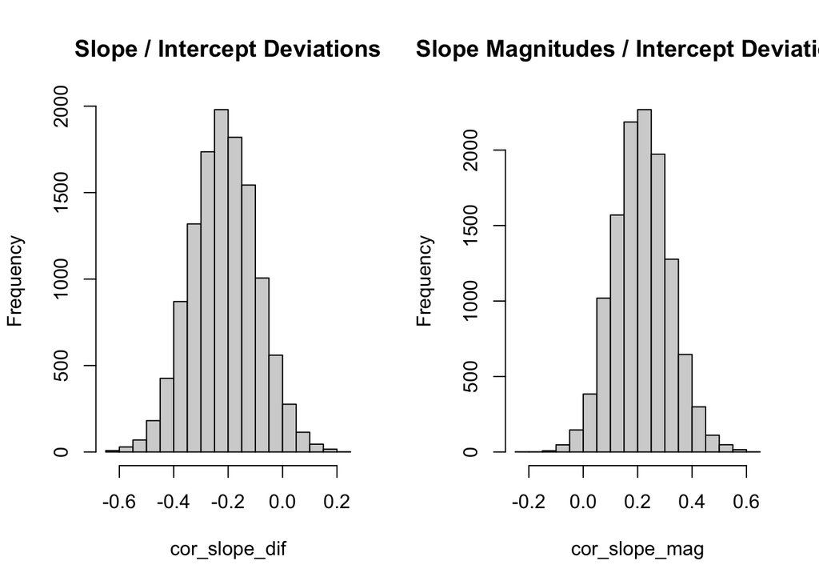

```r
# Look at distribution of correlation coefficients
par(mfrow = c(1, 2))
hist(cor_slope_dif, main = "Slope / Intercept Deviations")
hist(cor_slope_mag, main = "Slope Magnitudes / Intercept Deviations")
```

## Personality & Predictability & Plasticity (DHGLM - Random Slope)

### Model

In this section we are modelling a random slope and intercept in the mean model, and a random intercept in the dispersion model. We will also estimate the correlation between slopes and intercepts across the models.

```r
######## Personality/Plasticity/Predictability ###################
######## stan_personality_plasticity_dhglm_aggression <- stan(file =
######## './Code/stancode_personality_plasticity_dhglm.stan', data =
######## standata_personality_plasticity_dhglm_aggression, pars = save_pars,
######## iter = 6000, warmup = 2000, chains = 3, cores = 3)

rerun4 = FALSE

if (rerun4) {
    formula_personality_plasticity_dhglm_aggression <- bf(aggression ~ sex + age.Z +
        (1 + age.Z | q | id), sigma ~ sex + age.Z + (1 | q | id))

    brms_personality_plasticity_dhglm_aggression <- brm(formula_personality_plasticity_dhglm_aggression,
        data = dat, iter = 6000, warmup = 2000, chains = 3, cores = 3, save_pars = save_pars())
    saveRDS(brms_personality_plasticity_dhglm_aggression, "./Models/brms_models/brms_personality_plasticity_dhglm_aggression")
} else {
    brms_personality_plasticity_dhglm_aggression <- readRDS(here::here("Models/brms_models",
        "brms_personality_plasticity_dhglm_aggression"))
}

summary(brms_personality_plasticity_dhglm_aggression)
```

```
##  Family: gaussian
##   Links: mu = identity; sigma = log
## Formula: aggression ~ sex + age.Z + (1 + age.Z | q | id)
##          sigma ~ sex + age.Z + (1 | q | id)
##    Data: dat (Number of observations: 2766)
## Samples: 3 chains, each with iter = 6000; warmup = 2000; thin = 1;
##          total post-warmup samples = 12000
##
## Group-Level Effects:
## ~id (Number of levels: 248)
##                                Estimate Est.Error l-95% CI u-95% CI Rhat
## sd(Intercept)                      0.44      0.03     0.39     0.49 1.00
## sd(age.Z)                          0.17      0.02     0.13     0.22 1.00
## sd(sigma_Intercept)                0.23      0.02     0.19     0.28 1.00
## cor(Intercept,age.Z)              -0.24      0.12    -0.48     0.01 1.00
## cor(Intercept,sigma_Intercept)     0.36      0.11     0.15     0.56 1.00
## cor(age.Z,sigma_Intercept)         0.51      0.15     0.21     0.77 1.00
##                                Bulk_ESS Tail_ESS
## sd(Intercept)                      4230     7021
## sd(age.Z)                          4410     7030
## sd(sigma_Intercept)                4416     7834
## cor(Intercept,age.Z)               6450     8553
## cor(Intercept,sigma_Intercept)     6024     7770
## cor(age.Z,sigma_Intercept)         2086     4352
##
## Population-Level Effects:
##                 Estimate Est.Error l-95% CI u-95% CI Rhat Bulk_ESS Tail_ESS
## Intercept           0.23      0.04     0.14     0.32 1.00     4949     7219
## sigma_Intercept    -0.22      0.03    -0.28    -0.16 1.00     7675     8190
## sexmale            -0.49      0.06    -0.61    -0.37 1.00     4194     6275
## age.Z              -0.29      0.02    -0.33    -0.25 1.00    10519     9789
## sigma_sexmale      -0.12      0.04    -0.20    -0.03 1.00     9220     9012
## sigma_age.Z        -0.10      0.02    -0.13    -0.07 1.00    12456     9606
##
## Samples were drawn using sampling(NUTS). For each parameter, Bulk_ESS
## and Tail_ESS are effective sample size measures, and Rhat is the potential
## scale reduction factor on split chains (at convergence, Rhat = 1).
```

### Calculate CVm and Rpm from Random Slope Model

Random regression for both the mean and dispersion model requires some modifications to calculate repeatability and the coefficient of variation. ‘**’ in the annotated steps below indicate what changes from previous models.

```r
################################# Mean and Dispersion Parameters

# (Step 1): Extract the population coefficients for mean model
B0_m <- brms::posterior_samples(brms_personality_plasticity_dhglm_aggression, pars = "b_Intercept")[,
    1]
B1_m <- brms::posterior_samples(brms_personality_plasticity_dhglm_aggression, pars = "b_sex")[,
    1]
B2_m <- brms::posterior_samples(brms_personality_plasticity_dhglm_aggression, pars = "b_age.Z")[,
    1]

mean(B0_m)
mean(stanproc_personality_plasticity_dhglm_aggression$B1_m0)

mean(B1_m)
mean(stanproc_personality_plasticity_dhglm_aggression$B1_m1)

mean(B2_m)
mean(stanproc_personality_plasticity_dhglm_aggression$B1_m2)

# (Step 2): Extract the population coefficients for dispersion model\t
B0_sd_exp <- brms::posterior_samples(brms_personality_plasticity_dhglm_aggression,
    pars = "b_sigma_Intercept")[, 1]
B1_sd_exp <- brms::posterior_samples(brms_personality_plasticity_dhglm_aggression,
    pars = "b_sigma_sex")[, 1]
B2_sd_exp <- brms::posterior_samples(brms_personality_plasticity_dhglm_aggression,
    pars = "b_sigma_age.Z")[, 1]

mean(2 * B0_sd_exp)
mean(stanproc_personality_plasticity_dhglm_aggression$B1_v0)

mean(2 * B1_sd_exp)
mean(stanproc_personality_plasticity_dhglm_aggression$B1_v1)

mean(2 * B2_sd_exp)
mean(stanproc_personality_plasticity_dhglm_aggression$B1_v2)

# (Step 3): Extract the random ID intercept variance components for random
# intercept. Note that we model ln(sd) so we need to convert to variance scale
# by multipling by 2.
sigma_ID_m0 <- brms::posterior_samples(brms_personality_plasticity_dhglm_aggression,
    pars = "sd_id__Intercept")[, 1]

mean(sigma_ID_m0)
mean(stanproc_personality_plasticity_dhglm_aggression$sigma_ID1_m0)

sigma_ID_sd0 <- brms::posterior_samples(brms_personality_plasticity_dhglm_aggression,
    pars = "sd_id__sigma_Intercept")[, 1]
sigma_ID_v0 <- 2 * sigma_ID_sd0

mean(sigma_ID_v0)
mean(stanproc_personality_plasticity_dhglm_aggression$sigma_ID1_v0)

# (Step 4): **New step as we now have a sd for the random slopes.**
sigma_ID_m2 <- brms::posterior_samples(brms_personality_plasticity_dhglm_aggression,
    pars = "sd_id__age.Z")[, 1]

mean(sigma_ID_m2)
mean(stanproc_personality_plasticity_dhglm_aggression$sigma_ID1_m2)

# (Step 5): Calculate the fixed effect variance for the mean model
# (var_fixed_m) and the dispersion model (B_pv). Note here that the
# calculations are the same because we assume intercept at an average age.
B_pm <- func_Bp(B0 = B0_m, B1 = B1_m)
B_pv <- 2 * func_Bp(B0 = B0_sd_exp, B1 = B1_sd_exp)

mean(B_pm)
mean(stanproc_personality_plasticity_dhglm_aggression$B1_pm)

mean(B_pv)
mean(stanproc_personality_plasticity_dhglm_aggression$B1_pv)

# (Step 6): Calculate the population intercept for the mean model (var_fixed_m)
# and dispersion model (var_fixed_v). Note that a variance on the ln(sd) scale
# can be converted to a ln(var) by multipling by 4. See supplemental text.
var_fixed_m <- func_var_fixed(B1 = B1_m, B2 = B2_m, data = dat)
var_fixed_v <- 4 * func_var_fixed(B1 = B1_sd_exp, B2 = B2_sd_exp, data = dat)

mean(var_fixed_m)
mean(stanproc_personality_plasticity_dhglm_aggression$var1_fixed_m)

mean(var_fixed_v)
mean(stanproc_personality_plasticity_dhglm_aggression$var1_fixed_v)

################################### Mean Model - Repeatability and CV

# (Step 1): ** Calculate average within-individual / residual variance **
sigma_w <- func_var_within(Bpv = B_pv, sigma_v0 = sigma_ID_v0, var_fixed_v = var_fixed_v)

mean(sigma_w)
mean(stanproc_personality_plasticity_dhglm_aggression$sigma1_w)

# (Step 2): Calculate total phenotypic variance. Note here that we add in the
# random slope variance now
var_p <- func_sum_var(vars = data.frame(sigma_ID_m0^2, sigma_ID_m2^2, var_fixed_m,
    sigma_w^2))

mean(var_p)
mean(stanproc_personality_plasticity_dhglm_aggression$var1_p)

# (Step 3): Calculate repeatability
Rp_mu <- sigma_ID_m0^2/var_p

mean(Rp_mu)
mean(stanproc_personality_plasticity_dhglm_aggression$Rp1_mu)

# (Step 4): Convert back from z-scale to calculate CVm
mu_unscaled <- mean(dat$stim.dist_0_5cm_dur_Aggression)
sigma_unscaled <- sd(dat$stim.dist_0_5cm_dur_Aggression)

Mu <- B_pm * sigma_unscaled + mu_unscaled
Sigma <- sqrt(var_p) * sigma_unscaled
indiv_sd <- sigma_ID_m0 * sigma_unscaled

# (Step 5): Calculate CVm for mean model
CV_mu <- indiv_sd/Mu

mean(CV_mu)
mean(stanproc_personality_plasticity_dhglm_aggression$CV1_mu)

################################### Dispersion Model - Repeatability and CV

# (Step 1): Calculate repeatability for the dispersion model
Rp_var <- func_Rp_var(Bpv = B_pv, sigma_v0 = sigma_ID_v0, var_fixed_v = var_fixed_v,
    var_p = var_p)

mean(Rp_var)
mean(stanproc_personality_plasticity_dhglm_aggression$Rp1_var)

# (Step 2): ** Sum of IDv0 (intercept), and fixedV = total variance in residual
# variance on log-normal scale. See eqn 39. in MS.**
var_residvar_exp <- func_sum_var(vars = data.frame(sigma_ID_v0^2, var_fixed_v))

# (Step 3): Converting back to same scale as mean model
sigma_residvar <- func_ln_convert(mu_ln = B_pv, sigma_ln = sqrt(var_residvar_exp))$sigma_raw

# (Step 4): Getting variance in individual component through the preservation
# of the proportionality (i.e. ratio method)
ratio <- sigma_ID_v0^2/(var_residvar_exp)
var_ID <- sigma_residvar^2 * ratio

# (Step 5): Calculate coefficient of variation
CV_var <- sqrt(var_ID)/sigma_w^2

mean(CV_var)
mean(stanproc_personality_plasticity_dhglm_aggression$CV1_var)
```

| Model | Estimate Type | Mean Estimate | 95% CIlower | 95% CIupper |
| --- | --- | --- | --- | --- |
| Mean Model | Rpm | 0.253 | 0.203 | 0.308 |
|  | CVm | 0.277 | 0.245 | 0.313 |
| Dispersion Model | Rpv | 0.068 | 0.046 | 0.091 |
|  | CVv | 0.756 | 0.610 | 0.910 |

### Associations between Personality, Plasticity, and Predictability

```r
# PERSONALITY-PLASTICITY ASSOCIATIONS Equation 8: correlation between intercept
# and slope deviations
brms_cor_ID1_m0_ID1_m2 <- brms::posterior_samples(brms_personality_plasticity_dhglm_aggression,
    pars = "cor_id__Intercept__age.Z", fixed = TRUE)[, 1]

mean(brms_cor_ID1_m0_ID1_m2)
mean(stanproc_personality_plasticity_dhglm_aggression$cor_ID1_m0_ID1_m2)

# Equation 9: correlation between intercept differences and slope magnitudes
# Extract blups
blups_IDm0 <- brms::posterior_samples(brms_personality_plasticity_dhglm_aggression,
    pars = "r_id[[1-9].*,Intercept]")
blups_IDm2 <- brms::posterior_samples(brms_personality_plasticity_dhglm_aggression,
    pars = "r_id[[1-9].*,age.Z]")
B_m2 <- brms::posterior_samples(brms_personality_plasticity_dhglm_aggression, pars = "b_age.Z",
    fixed = TRUE)[, 1]

# Calculate the absolute magnitude of individuals slope and each individuals
# slope deviation (Eqn. 9 of main manuscript)
abs_slope <- apply(blups_IDm2, 2, function(x) abs(B_m2 + x))

# Using absolute slope and the individual deviations for each individuals
# intercept calculate the correlation across the 248 fish for each posterior
# sample of individual blups
cor_ID1_m0_ID1_slope <- cor_calc(slopes = abs_slope, intercepts = blups_IDm0)

mean(cor_ID1_m0_ID1_slope)
mean(stanproc_personality_plasticity_dhglm_aggression$personality_plasticity_association1)

# PERSONALITY-PREDICTABILITY ASSOCIATIONS Equation 22: sign-reversed
# correlation between mean and dispersion intercepts
brms_personality_predictability_association <- -1 * brms::posterior_samples(brms_personality_plasticity_dhglm_aggression,
    pars = "cor_id__Intercept__sigma_Intercept", fixed = TRUE)[, 1]
mean(brms_personality_predictability_association)
mean(stanproc_personality_plasticity_dhglm_aggression$personality_predictability_association1)

# PLASTICITY-PREDICTABILITY ASSOCIATIONS Equation 23: correlation between
# intercepts pulled from the model
brms_cor_ID1_m2_ID1_v0 <- brms::posterior_samples(brms_personality_plasticity_dhglm_aggression,
    pars = "cor_id__age.Z__sigma_Intercept", fixed = TRUE)[, 1]
# note that a positive correlation indicates *less* predictability, because a
# greater V0 = more variance
mean(brms_cor_ID1_m2_ID1_v0)
mean(stanproc_personality_plasticity_dhglm_aggression$cor_ID1_m2_ID1_v0)

# Equation 24: slope magnitudes and sign-reversed predictability differences
blups_IDv0_reversed <- -1 * brms::posterior_samples(brms_personality_plasticity_dhglm_aggression,
    pars = "r_id__sigma[[1-9].*,Intercept]")
brms_plasticity_predictability_association <- cor_calc(abs_slope, blups_IDv0_reversed)
mean(brms_plasticity_predictability_association)
mean(stanproc_personality_plasticity_dhglm_aggression$plasticity_predictability_association1)
```

## Bi-variate Personality (SHGLM - Two Traits)

### Model

In this section we briefly show readers how they can fit a bi-variate model with aggression and activity, estimating intercepts within and among the traits at the individual-level. The principles for calculating repeatability and the coefficient of variation are the same as that outlined in Personality (SHGLM).

```r
############# Bi-variate Personality
############# ##############################################
############# stan_bivar_shglm_activity_aggression <- stan(file =
############# './Code/stancode_bivar_shglm.stan', data =
############# standata_bivar_shglm_activity_aggression, pars = save_pars, iter
############# = 6000, warmup = 2000, chains = 3, cores = 3)

rerun5 = FALSE

if (rerun5) {

    # Note that the random effect notation: (1 | q |...) is needed to define
    # whether you want to estimate correlations. Random effects with the same
    # letter (i.e., 'q') will indicate that one wished to model the correlation
    # between Y1 and Y2 id. If you change letters so that are different it will
    # not model the correlation. It is also one way to reduce how many
    # parameters are estimated.

    formula_bivar_shglm_aggression <- bf(aggression ~ sex + age.Z + (1 | q | id))
    formula_bivar_shglm_activity <- bf(activity ~ sex + age.Z + (1 | q | id))

    brms_bivar_shglm_activity_aggression <- brm(formula_bivar_shglm_aggression +
        formula_bivar_shglm_activity, data = dat, iter = 6000, warmup = 2000, chains = 3,
        cores = 3, save_pars = save_pars())
    saveRDS(brms_bivar_shglm_activity_aggression, "./Models/brms_models/brms_bivar_shglm_activity_aggression")
} else {
    brms_bivar_shglm_activity_aggression <- readRDS(here::here("Models/brms_models",
        "brms_bivar_shglm_activity_aggression"))
}

summary(brms_bivar_shglm_activity_aggression)
```

```
##  Family: MV(gaussian, gaussian)
##   Links: mu = identity; sigma = identity
##          mu = identity; sigma = identity
## Formula: aggression ~ sex + age.Z + (1 | q | id)
##          activity ~ sex + age.Z + (1 | q | id)
##    Data: dat (Number of observations: 2766)
## Samples: 3 chains, each with iter = 6000; warmup = 2000; thin = 1;
##          total post-warmup samples = 12000
##
## Group-Level Effects:
## ~id (Number of levels: 248)
##                                              Estimate Est.Error l-95% CI
## sd(aggression_Intercept)                         0.43      0.03     0.38
## sd(activity_Intercept)                           0.64      0.03     0.58
## cor(aggression_Intercept,activity_Intercept)    -0.04      0.08    -0.19
##                                              u-95% CI Rhat Bulk_ESS Tail_ESS
## sd(aggression_Intercept)                         0.49 1.00     3295     5639
## sd(activity_Intercept)                           0.71 1.00     2052     4382
## cor(aggression_Intercept,activity_Intercept)     0.12 1.00      950     1934
##
## Population-Level Effects:
##                      Estimate Est.Error l-95% CI u-95% CI Rhat Bulk_ESS
## aggression_Intercept     0.24      0.04     0.16     0.33 1.00     2817
## activity_Intercept      -0.10      0.06    -0.22     0.01 1.00     1272
## aggression_sexmale      -0.51      0.06    -0.64    -0.39 1.00     2565
## aggression_age.Z        -0.31      0.02    -0.34    -0.28 1.00    14842
## activity_sexmale         0.21      0.09     0.03     0.38 1.00     1274
## activity_age.Z          -0.21      0.01    -0.23    -0.18 1.00    12572
##                      Tail_ESS
## aggression_Intercept     5063
## activity_Intercept       2555
## aggression_sexmale       4727
## aggression_age.Z         9065
## activity_sexmale         2525
## activity_age.Z           8236
##
## Family Specific Parameters:
##                  Estimate Est.Error l-95% CI u-95% CI Rhat Bulk_ESS Tail_ESS
## sigma_aggression     0.82      0.01     0.80     0.85 1.00    13203     9126
## sigma_activity       0.74      0.01     0.72     0.76 1.00    12277     9113
##
## Residual Correlations:
##                             Estimate Est.Error l-95% CI u-95% CI Rhat Bulk_ESS
## rescor(aggression,activity)     0.08      0.02     0.04     0.12 1.00    12035
##                             Tail_ESS
## rescor(aggression,activity)     9075
##
## Samples were drawn using sampling(NUTS). For each parameter, Bulk_ESS
## and Tail_ESS are effective sample size measures, and Rhat is the potential
## scale reduction factor on split chains (at convergence, Rhat = 1).
```

## Bi-variate Personality & Plasticity & Predictability (DHGLM - Two Traits)

### Model

In this section we briefly show readers how they can fit a bi-variate model with aggression and activity, estimating intercepts, slopes and correlations within and among the traits. The principles for calculating repeatability and the coefficient of variation are the same as that outlined in Personality & Predictability (DHGLM).

```r
######## Bi-variate Personality/Predictability/Plasticity
######## ######################################
######## stan_bivar_dhglm_activity_aggression <- stan(file =
######## './Code/stancode_bivar_dhglm.stan', \t\t\t\t\t\t\t\t\t\t\tdata =
######## \tstandata_bivar_dhglm_activity_aggression, \t\t\t\t\t\t\t\t\t\t\tpars
######## = save_pars, iter = 6000, warmup = 2000, chains = 3, cores = 3)

rerun6 = FALSE

if (rerun6) {
    # Note that the random effect notation: (1 | q |...) is needed to define
    # whether you want to estimate correlations. Random effects with the same
    # letter (i.e., 'q') will indicate that one wished to model the correlation
    # between Y1 and Y2 id, or say between sigma Y1 and Y2 etc. If you change
    # letters so that are different it will not model the correlation. It is
    # also one way to reduce how many parameters are estimated.

    formula_bivar_dhglm_aggression <- bf(aggression ~ sex + age.Z + (1 + age.Z |
        z | id), sigma ~ sex + age.Z + (1 | z | id))

    formula_bivar_dhglm_activity <- bf(activity ~ sex + age.Z + (1 + age.Z | z |
        id), sigma ~ sex + age.Z + (1 | z | id))

    brms_bivar_dhglm_activity_aggression <- brm(formula_bivar_dhglm_aggression +
        formula_bivar_dhglm_activity, data = dat, iter = 6000, warmup = 2000, chains = 3,
        cores = 3, save_pars = save_pars())
    saveRDS(brms_bivar_dhglm_activity_aggression, "./Models/brms_models/brms_bivar_dhglm_activity_aggression")

} else {
    brms_bivar_dhglm_activity_aggression <- readRDS(here::here("Models/brms_models",
        "brms_bivar_dhglm_activity_aggression"))
}

summary(brms_bivar_dhglm_activity_aggression)
```

```
##  Family: MV(gaussian, gaussian)
##   Links: mu = identity; sigma = log
##          mu = identity; sigma = log
## Formula: aggression ~ sex + age.Z + (1 + age.Z | z | id)
##          sigma ~ sex + age.Z + (1 | z | id)
##          activity ~ sex + age.Z + (1 + age.Z | z | id)
##          sigma ~ sex + age.Z + (1 | z | id)
##    Data: dat (Number of observations: 2766)
## Samples: 3 chains, each with iter = 6000; warmup = 2000; thin = 1;
##          total post-warmup samples = 12000
##
## Group-Level Effects:
## ~id (Number of levels: 248)
##                                                          Estimate Est.Error
## sd(aggression_Intercept)                                     0.44      0.03
## sd(aggression_age.Z)                                         0.17      0.02
## sd(sigma_aggression_Intercept)                               0.23      0.02
## sd(activity_Intercept)                                       0.63      0.03
## sd(activity_age.Z)                                           0.20      0.02
## sd(sigma_activity_Intercept)                                 0.33      0.02
## cor(aggression_Intercept,aggression_age.Z)                  -0.21      0.12
## cor(aggression_Intercept,sigma_aggression_Intercept)         0.36      0.10
## cor(aggression_age.Z,sigma_aggression_Intercept)             0.44      0.13
## cor(aggression_Intercept,activity_Intercept)                -0.07      0.08
## cor(aggression_age.Z,activity_Intercept)                    -0.16      0.11
## cor(sigma_aggression_Intercept,activity_Intercept)          -0.64      0.07
## cor(aggression_Intercept,activity_age.Z)                     0.02      0.10
## cor(aggression_age.Z,activity_age.Z)                        -0.22      0.15
## cor(sigma_aggression_Intercept,activity_age.Z)              -0.41      0.12
## cor(activity_Intercept,activity_age.Z)                       0.62      0.07
## cor(aggression_Intercept,sigma_activity_Intercept)          -0.09      0.09
## cor(aggression_age.Z,sigma_activity_Intercept)               0.14      0.13
## cor(sigma_aggression_Intercept,sigma_activity_Intercept)     0.58      0.09
## cor(activity_Intercept,sigma_activity_Intercept)            -0.48      0.07
## cor(activity_age.Z,sigma_activity_Intercept)                -0.59      0.09
##                                                          l-95% CI u-95% CI Rhat
## sd(aggression_Intercept)                                     0.39     0.50 1.00
## sd(aggression_age.Z)                                         0.13     0.22 1.00
## sd(sigma_aggression_Intercept)                               0.19     0.27 1.00
## sd(activity_Intercept)                                       0.57     0.70 1.00
```

[output cut: 62 more lines]

```
## sigma_aggression_age.Z        10232
## activity_sexmale               8957
## activity_age.Z                10319
## sigma_activity_sexmale         9189
## sigma_activity_age.Z           9975
##
## Residual Correlations:
##                             Estimate Est.Error l-95% CI u-95% CI Rhat Bulk_ESS
## rescor(aggression,activity)     0.06      0.02     0.02     0.10 1.00    15449
##                             Tail_ESS
## rescor(aggression,activity)    10091
##
## Samples were drawn using sampling(NUTS). For each parameter, Bulk_ESS
## and Tail_ESS are effective sample size measures, and Rhat is the potential
## scale reduction factor on split chains (at convergence, Rhat = 1).
```

### Associations between Personality, Plasticity, and Predictability

```r
# (brms_bivar_dhglm_activity_aggression$fit@sim$samples[[1]] %>% names())[1:40]
# # names of parameters

# PERSONALITY-PLASTICITY ASSOCIATIONS Equation 8: correlation between intercept
# and slope deviations
brms_cor_ID1_m0_ID1_m2 <- brms::posterior_samples(brms_bivar_dhglm_activity_aggression,
    pars = "cor_id__activity_Intercept__activity_age.Z", fixed = TRUE)[, 1]
brms_cor_ID2_m0_ID2_m2 <- brms::posterior_samples(brms_bivar_dhglm_activity_aggression,
    pars = "cor_id__aggression_Intercept__aggression_age.Z", fixed = TRUE)[, 1]

mean(brms_cor_ID1_m0_ID1_m2)
mean(stanproc_bivar_dhglm_activity_aggression$cor_ID1_m0_ID1_m2)

mean(brms_cor_ID2_m0_ID2_m2)
mean(stanproc_bivar_dhglm_activity_aggression$cor_ID2_m0_ID2_m2)

# Equation 9: correlation between intercept differences and slope magnitudes
# Extract blups
blups_ID1_m0 <- brms::posterior_samples(brms_bivar_dhglm_activity_aggression, pars = "r_id__activity[[1-9].*,Intercept]")
blups_ID1_m2 <- brms::posterior_samples(brms_bivar_dhglm_activity_aggression, pars = "r_id__activity[[1-9].*,age.Z]")
B1_m2 <- brms::posterior_samples(brms_bivar_dhglm_activity_aggression, pars = "b_activity_age.Z",
    fixed = TRUE)[, 1]

blups_ID2_m0 <- brms::posterior_samples(brms_bivar_dhglm_activity_aggression, pars = "r_id__aggression[[1-9].*,Intercept]")
blups_ID2_m2 <- brms::posterior_samples(brms_bivar_dhglm_activity_aggression, pars = "r_id__aggression[[1-9].*,age.Z]")
B2_m2 <- brms::posterior_samples(brms_bivar_dhglm_activity_aggression, pars = "b_aggression_age.Z",
    fixed = TRUE)[, 1]

# Calculate the absolute magnitude of individuals slope and each individuals
# slope deviation (Eqn. 9 of main manuscript)
abs_slope1 <- apply(blups_ID1_m2, 2, function(x) abs(B1_m2 + x))
abs_slope2 <- apply(blups_ID2_m2, 2, function(x) abs(B2_m2 + x))

# Using absolute slope and the individual deviations for each individuals
# intercept calculate the correlation across the 248 fish for each posterior
# sample of individual blups
cor_ID1_m0_ID1_slope <- cor_calc(slopes = abs_slope1, intercepts = blups_ID1_m0)
cor_ID2_m0_ID2_slope <- cor_calc(slopes = abs_slope2, intercepts = blups_ID2_m0)

mean(cor_ID1_m0_ID1_slope)
mean(stanproc_bivar_dhglm_activity_aggression$personality_plasticity_association1)

mean(cor_ID2_m0_ID2_slope)
mean(stanproc_bivar_dhglm_activity_aggression$personality_plasticity_association2)

# PERSONALITY-PREDICTABILITY ASSOCIATIONS Equation 22: sign-reversed
# correlation between mean and dispersion intercepts
brms_personality_predictability_association1 <- -1 * brms::posterior_samples(brms_bivar_dhglm_activity_aggression,
    pars = "cor_id__activity_Intercept__sigma_activity_Intercept", fixed = TRUE)[,
    1]
brms_personality_predictability_association2 <- -1 * brms::posterior_samples(brms_bivar_dhglm_activity_aggression,
    pars = "cor_id__aggression_Intercept__sigma_aggression_Intercept", fixed = TRUE)[,
    1]

mean(brms_personality_predictability_association1)
mean(stanproc_bivar_dhglm_activity_aggression$personality_predictability_association1)

mean(brms_personality_predictability_association2)
mean(stanproc_bivar_dhglm_activity_aggression$personality_predictability_association2)


# PLASTICITY-PREDICTABILITY ASSOCIATIONS Equation 23: correlation between
# intercepts pulled from the model
brms_cor_ID1_m2_ID1_v0 <- brms::posterior_samples(brms_bivar_dhglm_activity_aggression,
    pars = "cor_id__activity_age.Z__sigma_activity_Intercept", fixed = TRUE)[, 1]
brms_cor_ID2_m2_ID2_v0 <- brms::posterior_samples(brms_bivar_dhglm_activity_aggression,
    pars = "cor_id__aggression_age.Z__sigma_aggression_Intercept", fixed = TRUE)[,
    1]
# note that a positive correlation indicates *less* predictability, because a
# greater V0 = more variance
mean(brms_cor_ID1_m2_ID1_v0)
mean(stanproc_bivar_dhglm_activity_aggression$cor_ID1_m2_ID1_v0)

mean(brms_cor_ID2_m2_ID2_v0)
mean(stanproc_bivar_dhglm_activity_aggression$cor_ID2_m2_ID2_v0)

# Equation 24: slope magnitudes and sign-reversed predictability differences
blups_ID1_v0_reversed <- -1 * brms::posterior_samples(brms_bivar_dhglm_activity_aggression,
    pars = "r_id__sigma_activity[[1-9].*,Intercept]")
brms_plasticity_predictability_association1 <- cor_calc(abs_slope1, blups_ID1_v0_reversed)
mean(brms_plasticity_predictability_association1)
mean(stanproc_bivar_dhglm_activity_aggression$plasticity_predictability_association1)

blups_ID2_v0_reversed <- -1 * brms::posterior_samples(brms_bivar_dhglm_activity_aggression,
    pars = "r_id__sigma_aggression[[1-9].*,Intercept]")
brms_plasticity_predictability_association2 <- cor_calc(abs_slope2, blups_ID2_v0_reversed)
mean(brms_plasticity_predictability_association2)
mean(stanproc_bivar_dhglm_activity_aggression$plasticity_predictability_association2)
```

### Personality, Plasticity, and Predictability Syndromes

Between-trait correlations in individual differences in mean intercepts, slopes, and dispersion intercepts

```r
# Equation 14: Behavioural Syndromes
brms_cor_ID1_m0_ID2_m0 <- brms::posterior_samples(brms_bivar_dhglm_activity_aggression,
    pars = "cor_id__aggression_Intercept__activity_Intercept", fixed = TRUE)[, 1]
mean(brms_cor_ID1_m0_ID2_m0)
mean(stanproc_bivar_dhglm_activity_aggression$cor_ID1_m0_ID2_m0)

# Equation 15: Plasticity syndromes, slope differences
brms_cor_ID1_m2_ID2_m2 <- brms::posterior_samples(brms_bivar_dhglm_activity_aggression,
    pars = "cor_id__aggression_age.Z__activity_age.Z", fixed = TRUE)[, 1]
mean(brms_cor_ID1_m2_ID2_m2)
mean(stanproc_bivar_dhglm_activity_aggression$cor_ID1_m2_ID2_m2)

# Equation 16: Plasticity syndromes, slope magnitudes Extract blups
blups_ID1_m2 <- brms::posterior_samples(brms_bivar_dhglm_activity_aggression, pars = "r_id__aggression[[1-9].*,age.Z]")
blups_ID2_m2 <- brms::posterior_samples(brms_bivar_dhglm_activity_aggression, pars = "r_id__activity[[1-9].*,age.Z]")
# population slopes
B1_m2 <- brms::posterior_samples(brms_bivar_dhglm_activity_aggression, pars = "b_aggression_age.Z",
    fixed = TRUE)[, 1]
B2_m2 <- brms::posterior_samples(brms_bivar_dhglm_activity_aggression, pars = "b_activity_age.Z",
    fixed = TRUE)[, 1]

# Calculate the absolute magnitude of individuals slope and each individuals
# slope deviation (Eqn. 9 of main manuscript)
abs_slope1 <- apply(blups_ID1_m2, 2, function(x) abs(B1_m2 + x))
abs_slope2 <- apply(blups_ID2_m2, 2, function(x) abs(B2_m2 + x))

# Using absolute slope and the individual deviations for each individuals
# intercept calculate the correlation across the 248 fish for each posterior
# sample of individual blups
cor_slope_mag <- cor_calc(abs_slope1, intercepts = abs_slope2)

mean(cor_slope_mag)
mean(stanproc_bivar_dhglm_activity_aggression$plasticity_syndrome)

# Equation 31: Predictability syndrome
brms_cor_ID1_v0_ID2_v0 <- brms::posterior_samples(brms_bivar_dhglm_activity_aggression,
    pars = "cor_id__sigma_aggression_Intercept__sigma_activity_Intercept", fixed = TRUE)[,
    1]
mean(brms_cor_ID1_v0_ID2_v0)
mean(stanproc_bivar_dhglm_activity_aggression$cor_ID1_v0_ID2_v0)
```